# RQ1.2 Democratic Candidate Choice Models

- Show All Code
- Hide All Code
- View Source

How do feelings about the future affect young people’s democratic candidate choices?

```r
load(here(data_dir, "analysis", "df_long.RData"))

df_long <- df_long |>
  mutate(conjoint_choice = as.numeric(conjoint_choice),
         conjoint_sex = factor(conjoint_sex, levels = c("Male", "Female")),
         conjoint_age = as.numeric(conjoint_age),
         conjoint_party = factor(conjoint_party,
                                 levels = c("Labour", "Conservatives", "Liberal Democrats",
                                            "Green Party", "Reform UK")),
         conjoint_dem = factor(conjoint_dem,
                     levels = c("undemocratic", "democratic"),
                     labels = c("Undemocratic", "Democratic")),
         conjoint_eco = factor(conjoint_eco,
                     levels = c("Neither good nor bad reputation on economic matters",
                                "Good at handling economic matters",
                                "Bad at handling economic matters"),
                     labels = c("Neither", "Economically good", "Economically bad"))) |>
  mutate(conjoint_age_z = standardise(conjoint_age))

# Variable lookup table for later
variable_lookup <- tibble(
  variable = c("conjoint_sex", "conjoint_age_z", "conjoint_party", "conjoint_dem", "conjoint_eco"),
  variable_nice = c("Sex", "Age", "Party", "Democratic behaviour", "Economic reputation")
)
```

```r
# brms settings
bayes_seed <- 42
chains <- 4
iter <- 4000
warmup <- floor(iter/2)
adapt_delta <- 0.90
max_treedepth <- 10
```

```r
# marginaleffects settings
options(marginaleffects_posterior_interval = "hdi")
options(marginaleffects_posterior_center = stats::median)
```

### Main Models

#### Model 0 — Conjoint Choices

```r
f_cj0 <- bf(conjoint_choice ~ conjoint_dem + conjoint_sex + conjoint_age_z + conjoint_party + conjoint_eco + (1 | id))

priors_cj0 <- c(
  prior(normal(0, 1), class = "Intercept"),
  prior(normal(0, 1), class = "b"),
  prior(exponential(1), class = "sd")
)
```

```r
cj0 <- brm(
  data = df_long,
  family = bernoulli(link = "logit"),
  formula = f_cj0,
  prior = priors_cj0,
  sample_prior = "yes",
  init = "random",
  chains = chains,
  iter = iter,
  warmup = warmup,
  seed = bayes_seed,
  control = list(
    adapt_delta = adapt_delta,
    max_treedepth = max_treedepth),
  file = here(model_dir, "cj0.rds")
)
```

```r
print(cj0)
```

```
 Family: bernoulli
  Links: mu = logit
Formula: conjoint_choice ~ conjoint_dem + conjoint_sex + conjoint_age_z + conjoint_party + conjoint_eco + (1 | id)
   Data: df_long (Number of observations: 15160)
  Draws: 4 chains, each with iter = 4000; warmup = 2000; thin = 1;
         total post-warmup draws = 8000

Multilevel Hyperparameters:
~id (Number of levels: 1895)
              Estimate Est.Error l-95% CI u-95% CI Rhat Bulk_ESS Tail_ESS
sd(Intercept)     0.01      0.01     0.00     0.04 1.00     6944     4342

Regression Coefficients:
                               Estimate Est.Error l-95% CI u-95% CI Rhat Bulk_ESS Tail_ESS
Intercept                         -0.22      0.05    -0.31    -0.13 1.00    16071     5995
conjoint_demDemocratic             0.69      0.03     0.62     0.76 1.00    18398     5647
conjoint_sexFemale                 0.08      0.03     0.01     0.15 1.00    19816     5665
conjoint_age_z                    -0.08      0.02    -0.11    -0.04 1.00    22733     4795
conjoint_partyConservatives       -0.17      0.04    -0.26    -0.08 1.00    12164     6753
conjoint_partyLiberalDemocrats    -0.01      0.06    -0.13     0.10 1.00    13918     6870
conjoint_partyGreenParty           0.04      0.06    -0.06     0.15 1.00    13791     5619
conjoint_partyReformUK            -0.38      0.06    -0.50    -0.28 1.00    12623     6478
conjoint_ecoEconomicallygood       0.55      0.04     0.47     0.63 1.00    15245     6201
conjoint_ecoEconomicallybad       -0.75      0.04    -0.83    -0.66 1.00    16375     5771

Draws were sampled using sample(hmc). For each parameter, Bulk_ESS
and Tail_ESS are effective sample size measures, and Rhat is the potential
scale reduction factor on split chains (at convergence, Rhat = 1).
```

##### Quantities of Interest

Thanks go to Andrew Heiss and his [amazing blog](https://www.andrewheiss.com/blog/2023/07/25/conjoint-bayesian-frequentist-guide/#finding-conjoint-amces-and-marginal-means-bayesianly) from where I borrow much of this code!

###### Average Marginal Component Effects (AMCEs)

```r
cj0_slopes <- avg_slopes(cj0,
                         newdata = datagrid(id = unique(df_long$id))) |>
  as_tibble() |>
  select(Contrast = contrast,
         Median = estimate,
         "95% HDI Lower" = conf.low,
         "95% HDI Upper" = conf.high
  ) |>
  mutate(Contrast = if_else(Contrast == "dY/dX", "Age (1 SD increase)", Contrast),
         across(where(is.numeric), \(x) round(x, 3)))

cj0_slopes |> tt()
```

| Contrast | Median | 95% HDI Lower | 95% HDI Upper |
| --- | --- | --- | --- |
| Age (1 SD increase) | -0.018 | -0.026 | -0.010 |
| Democratic - Undemocratic | 0.147 | 0.133 | 0.162 |
| Economically bad - Neither | -0.184 | -0.205 | -0.165 |
| Economically good - Neither | 0.126 | 0.108 | 0.146 |
| Conservatives - Labour | -0.041 | -0.063 | -0.021 |
| Green Party - Labour | 0.011 | -0.015 | 0.038 |
| Liberal Democrats - Labour | -0.003 | -0.030 | 0.024 |
| Reform UK - Labour | -0.091 | -0.115 | -0.064 |
| Female - Male | 0.019 | 0.003 | 0.035 |

```r
cj0_slopes |> tt() |>
  save_tt(here(table_dir, "conjoint_amces.docx"), overwrite = TRUE)
```

```r
# Create levels for all variables
cj0_levels <- tibble(
  variable = c("conjoint_sex", "conjoint_age_z", "conjoint_party", "conjoint_dem", "conjoint_eco"),
  levels = "") |>
  mutate(levels = case_when(
    variable == "conjoint_sex" ~ list(levels(df_long$conjoint_sex)),
    variable == "conjoint_age_z" ~ list("1 SD increase"),
    variable == "conjoint_party" ~ list(levels(df_long$conjoint_party)),
    variable == "conjoint_dem" ~ list(levels(df_long$conjoint_dem)),
    variable == "conjoint_eco" ~ list(levels(df_long$conjoint_eco))
  )) |>
  unnest(levels) |>
  mutate(term = paste0(variable, levels))

# Calculate Average Marginal Effects and get Posterior Draws
cj0_mfx <- cj0 |>
  avg_slopes(newdata = datagrid(id = unique(df_long$id))) |>
  posterior_draws()

# Reshape Results (handle continuous and categorical separately)
cj0_mfx_nested <- cj0_mfx |>
  mutate(
    variable_level = if_else(
      term == "conjoint_age_z",
      "1 SD increase",
      str_extract(contrast, "^[^-]+(?= - )")
    )
  ) |>
  group_by(term, variable_level) |>
  nest()

# Join Data
cj0_plot_data <- cj0_levels |>
  left_join(
    cj0_mfx_nested,
    by = join_by(variable == term, levels == variable_level)
  ) |>
  mutate(data = map_if(data, is.null, ~ tibble(draw = 0, estimate = 0))) |>
  unnest(data) |>
  left_join(variable_lookup, by = join_by(variable)) |>
  mutate(across(c(levels, variable_nice), ~fct_inorder(.)))
```

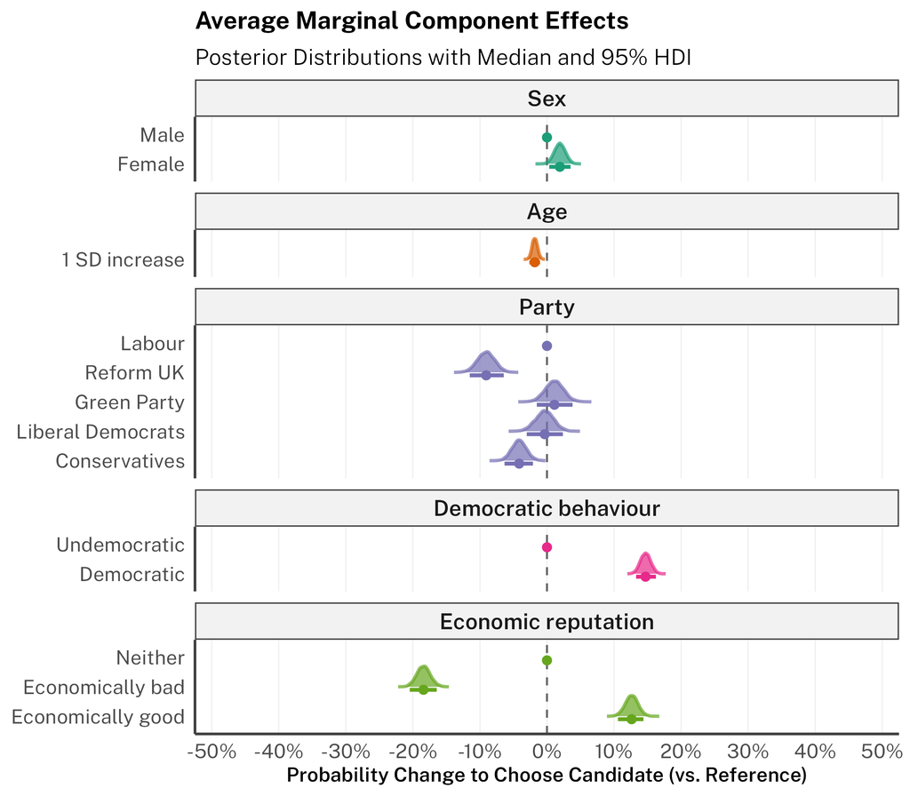

```r
cj0_plot_data |>

  ggplot(aes(x = draw, y = levels, fill = variable_nice, color = variable_nice)) +

  geom_vline(xintercept = 0, linetype = "dashed", color = "gray40", linewidth = 0.6) +

  stat_slab(
    data = ~filter(.x, draw != 0),
    aes(thickness = after_stat(pdf)),
    scale = 0.7,
    alpha = 0.7,
    normalize = "groups"
  ) +

  stat_pointinterval(
    .width = c(.95),
    point_interval = "median_hdi",
    position = position_nudge(y = -0.1),
    point_size = 2,
  ) +

  facet_col(facets = "variable_nice", scales = "free_y", space = "free") +

  scale_fill_brewer(palette = "Dark2") +
  scale_color_brewer(palette = "Dark2") +

  scale_x_continuous(
    labels = scales::percent,
    limits = c(-0.5, 0.5),
    breaks = seq(-0.5, 0.5, by = 0.1),
    expand = expansion(add = 0.025)
  ) +

  labs(
    x = "Probability Change to Choose Candidate (vs. Reference)",
    y = NULL,
    title = "Average Marginal Component Effects",
    subtitle = "Posterior Distributions with Median and 95% HDI"
  ) +

  theme_allround() +
  theme(
    legend.position = "none",
    panel.grid.major.x = element_line(color = "grey90", linewidth = 0.2)
  )
```

```r
ggsave(here(figure_dir, "conjoint_amce.svg"), height = 7, width = 8, web_fonts = falo_svg_fonts())
```

###### Marginal Means

```r
cj0_mm_sex <- avg_predictions(cj0, by = "conjoint_sex") |> as_tibble()
cj0_mm_party <- avg_predictions(cj0, by = "conjoint_party") |> as_tibble()
cj0_mm_dem <- avg_predictions(cj0, by = "conjoint_dem") |> as_tibble()
cj0_mm_eco <- avg_predictions(cj0, by = "conjoint_eco") |> as_tibble()
cj0_mm_age <- avg_predictions(cj0,
                              newdata = datagrid(conjoint_age_z = c(-1, 0, 1)),
                              by = "conjoint_age_z") |> as_tibble()

cj0_mm <- bind_rows(cj0_mm_sex, cj0_mm_party, cj0_mm_dem, cj0_mm_eco, cj0_mm_age)
```

```r
cj0_mm_table <- cj0_mm |>
  pivot_longer(
    cols = starts_with("conjoint_"),
    names_to = "Attribute",
    values_to = "Level",
    values_transform = as.character,
    values_drop_na = TRUE
  ) |>
  mutate(
    # Clean the Attribute names
    Attribute = Attribute |>
      str_remove("conjoint_") |>
      str_remove("_z") |>       # Removes "_z" from age
      str_to_title(),           # Capitalizes the first letter

    # Recode the Age Levels
    Level = case_when(
      Attribute == "Age" & Level == "-1" ~ "-1 SD",
      Attribute == "Age" & Level == "0"  ~ "Mean",
      Attribute == "Age" & Level == "1"  ~ "+1 SD",
      TRUE ~ Level
    )
  ) |>
  # Final Selection and Formatting
  select(
    Attribute,
    Level,
    Median = estimate,
    "95% HDI Lower" = conf.low,
    "95% HDI Upper" = conf.high
  ) |>
  mutate(across(where(is.numeric), \(x) round(x, 3)))

cj0_mm_table |> tt()
```

| Attribute | Level | Median | 95% HDI Lower | 95% HDI Upper |
| --- | --- | --- | --- | --- |
| Sex | Male | 0.489 | 0.478 | 0.500 |
| Sex | Female | 0.511 | 0.501 | 0.522 |
| Party | Labour | 0.516 | 0.502 | 0.530 |
| Party | Conservatives | 0.489 | 0.475 | 0.503 |
| Party | Liberal Democrats | 0.518 | 0.497 | 0.538 |
| Party | Green Party | 0.529 | 0.509 | 0.550 |
| Party | Reform UK | 0.444 | 0.423 | 0.464 |
| Dem | Undemocratic | 0.421 | 0.410 | 0.432 |
| Dem | Democratic | 0.579 | 0.568 | 0.590 |
| Eco | Neither | 0.516 | 0.502 | 0.530 |
| Eco | Economically good | 0.643 | 0.631 | 0.657 |
| Eco | Economically bad | 0.342 | 0.329 | 0.355 |
| Age | -1 SD | 0.408 | 0.383 | 0.433 |
| Age | Mean | 0.389 | 0.366 | 0.412 |
| Age | +1 SD | 0.371 | 0.348 | 0.395 |

#### Model 1 — Primary Model

```r
f_cj1 <- bf(conjoint_choice ~ conjoint_dem * exp_condition + conjoint_sex + conjoint_age_z + conjoint_party + conjoint_eco + (1 | id))

priors_cj1 <- c(
  prior(normal(0, 1), class = "Intercept"),
  prior(normal(0, 1), class = "b"),
  prior(exponential(1), class = "sd")
)
```

```r
cj1 <- brm(
  data = df_long,
  family = bernoulli(link = "logit"),
  formula = f_cj1,
  prior = priors_cj1,
  sample_prior = "yes",
  init = "random",
  chains = chains,
  iter = iter,
  warmup = warmup,
  seed = bayes_seed,
  control = list(
    adapt_delta = adapt_delta,
    max_treedepth = max_treedepth),
  file = here(model_dir, "cj1.rds")
)
```

```r
print(cj1)
```

```
 Family: bernoulli
  Links: mu = logit
Formula: conjoint_choice ~ conjoint_dem * exp_condition + conjoint_sex + conjoint_age_z + conjoint_party + conjoint_eco + (1 | id)
   Data: df_long (Number of observations: 15160)
  Draws: 4 chains, each with iter = 4000; warmup = 2000; thin = 1;
         total post-warmup draws = 8000

Multilevel Hyperparameters:
~id (Number of levels: 1895)
              Estimate Est.Error l-95% CI u-95% CI Rhat Bulk_ESS Tail_ESS
sd(Intercept)     0.01      0.01     0.00     0.04 1.00     7122     4158

Regression Coefficients:
                                            Estimate Est.Error l-95% CI u-95% CI Rhat Bulk_ESS Tail_ESS
Intercept                                      -0.22      0.06    -0.33    -0.11 1.00    10344     7269
conjoint_demDemocratic                          0.68      0.06     0.56     0.80 1.00     7877     6655
exp_conditionhope                              -0.01      0.06    -0.13     0.10 1.00     9687     6724
exp_conditionanxiety                            0.01      0.06    -0.11     0.12 1.00     9318     6902
conjoint_sexFemale                              0.08      0.03     0.01     0.15 1.00    19832     5047
conjoint_age_z                                 -0.08      0.02    -0.11    -0.04 1.00    24010     5004
conjoint_partyConservatives                    -0.17      0.04    -0.26    -0.09 1.00    11260     6948
conjoint_partyLiberalDemocrats                 -0.02      0.06    -0.12     0.09 1.00    12902     6434
conjoint_partyGreenParty                        0.04      0.06    -0.06     0.15 1.00    12417     6898
conjoint_partyReformUK                         -0.38      0.06    -0.49    -0.27 1.00    14947     6740
conjoint_ecoEconomicallygood                    0.55      0.04     0.47     0.63 1.00    15672     5648
conjoint_ecoEconomicallybad                    -0.75      0.04    -0.83    -0.67 1.00    17466     6611
conjoint_demDemocratic:exp_conditionhope        0.03      0.08    -0.13     0.19 1.00     8826     6899
conjoint_demDemocratic:exp_conditionanxiety     0.00      0.08    -0.17     0.16 1.00     8829     6940

Draws were sampled using sample(hmc). For each parameter, Bulk_ESS
and Tail_ESS are effective sample size measures, and Rhat is the potential
scale reduction factor on split chains (at convergence, Rhat = 1).
```

##### Quantities of Interest

###### Average Comparisons

```r
cj1_main_com <- avg_comparisons(cj1,
                                variables = list("conjoint_dem" = "pairwise")) |>
  as_tibble() |>
  select(Contrast = contrast,
         Median = estimate,
         "95% HDI Lower" = conf.low,
         "95% HDI Upper" = conf.high
  ) |>
  mutate(across(where(is.numeric), \(x) round(x, 3)))

cj1_main_com |> tt()
```

| Contrast | Median | 95% HDI Lower | 95% HDI Upper |
| --- | --- | --- | --- |
| Democratic - Undemocratic | 0.159 | 0.144 | 0.174 |

```r
cj1_com <- avg_comparisons(cj1,
                           variables = list("conjoint_dem" = "pairwise"),
                           by = "exp_condition") |>
  as_tibble() |>
  select(Contrast = contrast,
         Condition = exp_condition,
         Median = estimate,
         "95% HDI Lower" = conf.low,
         "95% HDI Upper" = conf.high
  ) |>
  mutate(across(where(is.numeric), \(x) round(x, 3)))

cj1_com |> tt()
```

| Contrast | Condition | Median | 95% HDI Lower | 95% HDI Upper |
| --- | --- | --- | --- | --- |
| Democratic - Undemocratic | control | 0.156 | 0.129 | 0.182 |
| Democratic - Undemocratic | hope | 0.163 | 0.138 | 0.190 |
| Democratic - Undemocratic | anxiety | 0.157 | 0.131 | 0.182 |

```r
cj1_hyp <- avg_comparisons(cj1,
                           variables = list("conjoint_dem" = "pairwise"),
                           by = "exp_condition",
                           hypothesis = ~pairwise) |>
  as_tibble() |>
  select(Hypothesis = hypothesis,
         Median = estimate,
         "95% HDI Lower" = conf.low,
         "95% HDI Upper" = conf.high
  ) |>
  mutate(across(where(is.numeric), \(x) round(x, 3)))

cj1_hyp |> tt()
```

| Hypothesis | Median | 95% HDI Lower | 95% HDI Upper |
| --- | --- | --- | --- |
| (hope) - (control) | 0.007 | -0.029 | 0.044 |
| (anxiety) - (control) | 0.000 | -0.038 | 0.037 |
| (anxiety) - (hope) | -0.007 | -0.043 | 0.030 |

###### Conditional Marginal Means

```r
cj1_mms <- predictions(
  cj1,
  by = c("conjoint_dem", "exp_condition"),
  allow_new_levels = TRUE) |>
  posterior_draws()

cj1_mms |>
  group_by(conjoint_dem, exp_condition) |>
  median_qi(draw) |>
  tt()
```

| conjoint_dem | exp_condition | draw | .lower | .upper | .width | .point | .interval |
| --- | --- | --- | --- | --- | --- | --- | --- |
| Undemocratic | control | 0.4213 | 0.4032 | 0.4406 | 0.95 | median | qi |
| Undemocratic | hope | 0.4194 | 0.4003 | 0.4381 | 0.95 | median | qi |
| Undemocratic | anxiety | 0.4213 | 0.4035 | 0.4399 | 0.95 | median | qi |
| Democratic | control | 0.5785 | 0.5601 | 0.5971 | 0.95 | median | qi |
| Democratic | hope | 0.5785 | 0.5601 | 0.5969 | 0.95 | median | qi |
| Democratic | anxiety | 0.5799 | 0.5612 | 0.5981 | 0.95 | median | qi |

#### Model 2 — Interaction with Age Group

```r
f_cj2 <- bf(conjoint_choice ~ conjoint_dem * exp_condition * age_group + conjoint_sex + conjoint_age_z + conjoint_party + conjoint_eco + (1 | id))
```

```r
cj2 <- brm(
  data = df_long,
  family = bernoulli(link = "logit"),
  formula = f_cj2,
  prior = priors_cj1,
  sample_prior = "yes",
  init = "random",
  chains = chains,
  iter = iter,
  warmup = warmup,
  seed = bayes_seed,
  control = list(
    adapt_delta = adapt_delta,
    max_treedepth = max_treedepth),
  file = here(model_dir, "cj2.rds")
)
```

```r
print(cj2)
```

```
 Family: bernoulli
  Links: mu = logit
Formula: conjoint_choice ~ conjoint_dem * exp_condition * age_group + conjoint_sex + conjoint_age_z + conjoint_party + conjoint_eco + (1 | id)
   Data: df_long (Number of observations: 15160)
  Draws: 4 chains, each with iter = 4000; warmup = 2000; thin = 1;
         total post-warmup draws = 8000

Multilevel Hyperparameters:
~id (Number of levels: 1895)
              Estimate Est.Error l-95% CI u-95% CI Rhat Bulk_ESS Tail_ESS
sd(Intercept)     0.01      0.01     0.00     0.04 1.00     6730     4393

Regression Coefficients:
                                                                Estimate Est.Error l-95% CI u-95% CI Rhat Bulk_ESS Tail_ESS
Intercept                                                          -0.24      0.07    -0.38    -0.11 1.00     4993     6197
conjoint_demDemocratic                                              0.70      0.08     0.54     0.86 1.00     3931     5750
exp_conditionhope                                                   0.01      0.08    -0.15     0.17 1.00     4234     5687
exp_conditionanxiety                                                0.03      0.08    -0.13     0.20 1.00     4482     5432
age_group22M26years                                                 0.05      0.08    -0.11     0.21 1.00     3847     5699
conjoint_sexFemale                                                  0.08      0.03     0.01     0.15 1.00    22319     5105
conjoint_age_z                                                     -0.08      0.02    -0.11    -0.04 1.00    20392     4901
conjoint_partyConservatives                                        -0.17      0.05    -0.26    -0.08 1.00    10945     6384
conjoint_partyLiberalDemocrats                                     -0.01      0.06    -0.12     0.09 1.00    12714     6759
conjoint_partyGreenParty                                            0.04      0.05    -0.06     0.15 1.00    12869     6700
conjoint_partyReformUK                                             -0.39      0.06    -0.50    -0.28 1.00    11482     5615
conjoint_ecoEconomicallygood                                        0.55      0.04     0.47     0.63 1.00    13703     6338
conjoint_ecoEconomicallybad                                        -0.75      0.04    -0.83    -0.66 1.00    15123     6670
conjoint_demDemocratic:exp_conditionhope                            0.02      0.12    -0.20     0.25 1.00     4284     5789
conjoint_demDemocratic:exp_conditionanxiety                        -0.02      0.12    -0.25     0.21 1.00     4358     5449
conjoint_demDemocratic:age_group22M26years                         -0.05      0.12    -0.27     0.18 1.00     3808     5218
exp_conditionhope:age_group22M26years                              -0.04      0.12    -0.27     0.19 1.00     4048     5653
exp_conditionanxiety:age_group22M26years                           -0.05      0.12    -0.29     0.17 1.00     4232     5706
conjoint_demDemocratic:exp_conditionhope:age_group22M26years        0.01      0.16    -0.31     0.32 1.00     4328     5383
conjoint_demDemocratic:exp_conditionanxiety:age_group22M26years     0.04      0.16    -0.28     0.37 1.00     4234     5756

Draws were sampled using sample(hmc). For each parameter, Bulk_ESS
and Tail_ESS are effective sample size measures, and Rhat is the potential
scale reduction factor on split chains (at convergence, Rhat = 1).
```

##### Quantities of Interest

AMCE of democratic behaviour within each age group (averaged across conditions):

```r
cj2_mod <- avg_comparisons(cj2,
                           variables = list("conjoint_dem" = "pairwise"),
                           by = "age_group")

cj2_mod |>
  as_tibble() |>
  select(Contrast = contrast,
         `Age Group` = age_group,
         Median = estimate,
         "95% HDI Lower" = conf.low,
         "95% HDI Upper" = conf.high
  ) |>
  mutate(across(where(is.numeric), \(x) round(x, 3))) |>
  tt()
```

| Contrast | Age Group | Median | 95% HDI Lower | 95% HDI Upper |
| --- | --- | --- | --- | --- |
| Democratic - Undemocratic | 16-21 years | 0.162 | 0.141 | 0.183 |
| Democratic - Undemocratic | 22-26 years | 0.155 | 0.134 | 0.177 |

Differences in the AMCE of democratic behaviour between age groups:

```r
cj2_mod_diffs <- avg_comparisons(cj2,
                                 variables = list("conjoint_dem" = "pairwise"),
                                 by = "age_group",
                                 hypothesis = difference ~ pairwise) |>
  as_tibble() |>
  select(`Age Group Difference` = hypothesis,
         Median = estimate,
         "95% HDI Lower" = conf.low,
         "95% HDI Upper" = conf.high
  ) |>
  mutate(across(where(is.numeric), \(x) round(x, 3)))

cj2_mod_diffs |> tt()
```

| Age Group Difference | Median | 95% HDI Lower | 95% HDI Upper |
| --- | --- | --- | --- |
| (22-26 years) - (16-21 years) | -0.007 | -0.037 | 0.023 |

Treatment effects on the AMCE of democratic behaviour within each age group:

```r
cj2_hyp <- avg_comparisons(cj2,
                           variables = list("conjoint_dem" = "pairwise"),
                           by = c("exp_condition", "age_group"),
                           hypothesis = difference ~ pairwise | age_group)

cj2_hyp |>
  as_tibble() |>
  select(Hypothesis = hypothesis,
         `Age Group` = age_group,
         Median = estimate,
         "95% HDI Lower" = conf.low,
         "95% HDI Upper" = conf.high
  ) |>
  mutate(across(where(is.numeric), \(x) round(x, 3))) |>
  tt()
```

| Hypothesis | Age Group | Median | 95% HDI Lower | 95% HDI Upper |
| --- | --- | --- | --- | --- |
| (hope) - (control) | 16-21 years | 0.006 | -0.044 | 0.059 |
| (anxiety) - (control) | 16-21 years | -0.005 | -0.059 | 0.044 |
| (anxiety) - (hope) | 16-21 years | -0.011 | -0.062 | 0.041 |
| (hope) - (control) | 22-26 years | 0.009 | -0.044 | 0.060 |
| (anxiety) - (control) | 22-26 years | 0.005 | -0.048 | 0.058 |
| (anxiety) - (hope) | 22-26 years | -0.003 | -0.056 | 0.048 |

Differences in the treatment effects between age groups:

```r
cj2_hyp_diffs <- cj2_hyp |>
  posterior_draws() |>
  select(drawid, hypothesis, age_group, draw) |>
  pivot_wider(names_from = age_group, values_from = draw) |>
  mutate(`(22-26 years) - (16-21 years)` = `22-26 years` - `16-21 years`) |>
  pivot_longer(starts_with("("), names_to = "difference", values_to = "estimate") |>
  group_by(hypothesis, difference) |>
  median_hdi(estimate, .width = 0.95) |>
  select(Hypothesis = hypothesis,
         `Age Group Difference` = difference,
         Median = estimate,
         "95% HDI Lower" = .lower,
         "95% HDI Upper" = .upper
  ) |>
  mutate(across(where(is.numeric), \(x) round(x, 3)))

cj2_hyp_diffs |> tt()
```

| Hypothesis | Age Group Difference | Median | 95% HDI Lower | 95% HDI Upper |
| --- | --- | --- | --- | --- |
| (anxiety) - (control) | (22-26 years) - (16-21 years) | 0.010 | -0.060 | 0.086 |
| (anxiety) - (hope) | (22-26 years) - (16-21 years) | 0.008 | -0.066 | 0.082 |
| (hope) - (control) | (22-26 years) - (16-21 years) | 0.003 | -0.069 | 0.075 |

#### Model 3 — Interaction with Gender

```r
f_cj3 <- bf(conjoint_choice ~ conjoint_dem * exp_condition * gender + conjoint_sex + conjoint_age_z + conjoint_party + conjoint_eco + (1 | id))
```

```r
cj3 <- brm(
  data = df_long,
  family = bernoulli(link = "logit"),
  formula = f_cj3,
  prior = priors_cj1,
  sample_prior = "yes",
  init = "random",
  chains = chains,
  iter = iter,
  warmup = warmup,
  seed = bayes_seed,
  control = list(
    adapt_delta = adapt_delta,
    max_treedepth = max_treedepth),
  file = here(model_dir, "cj3.rds")
)
```

```r
print(cj3)
```

```
 Family: bernoulli
  Links: mu = logit
Formula: conjoint_choice ~ conjoint_dem * exp_condition * gender + conjoint_sex + conjoint_age_z + conjoint_party + conjoint_eco + (1 | id)
   Data: df_long (Number of observations: 15160)
  Draws: 4 chains, each with iter = 4000; warmup = 2000; thin = 1;
         total post-warmup draws = 8000

Multilevel Hyperparameters:
~id (Number of levels: 1895)
              Estimate Est.Error l-95% CI u-95% CI Rhat Bulk_ESS Tail_ESS
sd(Intercept)     0.01      0.01     0.00     0.04 1.00     7975     4118

Regression Coefficients:
                                                         Estimate Est.Error l-95% CI u-95% CI Rhat Bulk_ESS Tail_ESS
Intercept                                                   -0.21      0.07    -0.36    -0.06 1.00     3964     4706
conjoint_demDemocratic                                       0.65      0.09     0.48     0.82 1.00     3020     4512
exp_conditionhope                                            0.04      0.08    -0.13     0.21 1.00     3710     4855
exp_conditionanxiety                                         0.09      0.08    -0.07     0.25 1.00     3311     4197
genderfemale                                                -0.01      0.08    -0.17     0.15 1.00     3267     4778
genderother                                                 -0.63      0.43    -1.49     0.17 1.00     7000     5754
conjoint_sexFemale                                           0.08      0.03     0.01     0.15 1.00    16749     5378
conjoint_age_z                                              -0.08      0.02    -0.11    -0.04 1.00    17500     5301
conjoint_partyConservatives                                 -0.17      0.05    -0.26    -0.08 1.00     9429     6554
conjoint_partyLiberalDemocrats                              -0.02      0.06    -0.13     0.09 1.00    10137     6364
conjoint_partyGreenParty                                     0.04      0.06    -0.07     0.16 1.00    10257     6007
conjoint_partyReformUK                                      -0.39      0.06    -0.50    -0.27 1.00    11140     6873
conjoint_ecoEconomicallygood                                 0.55      0.04     0.47     0.63 1.00    11857     6130
conjoint_ecoEconomicallybad                                 -0.75      0.04    -0.83    -0.66 1.00    11741     6295
conjoint_demDemocratic:exp_conditionhope                    -0.07      0.11    -0.30     0.15 1.00     3408     4457
conjoint_demDemocratic:exp_conditionanxiety                 -0.13      0.12    -0.36     0.10 1.00     3267     4797
conjoint_demDemocratic:genderfemale                          0.05      0.11    -0.17     0.28 1.00     3068     4777
conjoint_demDemocratic:genderother                           1.16      0.53     0.14     2.19 1.00     8214     6050
exp_conditionhope:genderfemale                              -0.12      0.12    -0.34     0.11 1.00     3714     5094
exp_conditionanxiety:genderfemale                           -0.18      0.11    -0.40     0.04 1.00     3602     4465
exp_conditionhope:genderother                                0.15      0.53    -0.90     1.20 1.00     7559     6396
exp_conditionanxiety:genderother                            -0.36      0.56    -1.47     0.72 1.00     9010     6380
conjoint_demDemocratic:exp_conditionhope:genderfemale        0.22      0.16    -0.10     0.54 1.00     3618     4395
conjoint_demDemocratic:exp_conditionanxiety:genderfemale     0.26      0.16    -0.06     0.58 1.00     3500     5258
conjoint_demDemocratic:exp_conditionhope:genderother        -0.05      0.65    -1.33     1.23 1.00     9583     6851
conjoint_demDemocratic:exp_conditionanxiety:genderother      0.49      0.68    -0.86     1.83 1.00     9693     7040

Draws were sampled using sample(hmc). For each parameter, Bulk_ESS
and Tail_ESS are effective sample size measures, and Rhat is the potential
scale reduction factor on split chains (at convergence, Rhat = 1).
```

##### Quantities of Interest

AMCE of democratic behaviour within each gender (averaged across conditions):

```r
cj3_mod <- avg_comparisons(cj3,
                           variables = list("conjoint_dem" = "pairwise"),
                           by = "gender")

cj3_mod |>
  as_tibble() |>
  select(Contrast = contrast,
         `Gender` = gender,
         Median = estimate,
         "95% HDI Lower" = conf.low,
         "95% HDI Upper" = conf.high
  ) |>
  mutate(across(where(is.numeric), \(x) round(x, 3))) |>
  tt()
```

| Contrast | Gender | Median | 95% HDI Lower | 95% HDI Upper |
| --- | --- | --- | --- | --- |
| Democratic - Undemocratic | male | 0.133 | 0.111 | 0.154 |
| Democratic - Undemocratic | female | 0.181 | 0.161 | 0.203 |
| Democratic - Undemocratic | other | 0.398 | 0.241 | 0.559 |

Differences in the AMCE of democratic behaviour between genders:

```r
cj3_mod_diffs <- avg_comparisons(cj3,
                                 variables = list("conjoint_dem" = "pairwise"),
                                 by = "gender",
                                 hypothesis = difference ~ pairwise) |>
  as_tibble() |>
  select(`Gender Difference` = hypothesis,
         Median = estimate,
         "95% HDI Lower" = conf.low,
         "95% HDI Upper" = conf.high
  ) |>
  mutate(across(where(is.numeric), \(x) round(x, 3)))

cj3_mod_diffs |> tt()
```

| Gender Difference | Median | 95% HDI Lower | 95% HDI Upper |
| --- | --- | --- | --- |
| (female) - (male) | 0.049 | 0.019 | 0.079 |
| (other) - (male) | 0.265 | 0.101 | 0.419 |
| (other) - (female) | 0.216 | 0.050 | 0.372 |

Treatment effects on the AMCE of democratic behaviour within each gender:

```r
cj3_hyp <- avg_comparisons(cj3,
                           variables = list("conjoint_dem" = "pairwise"),
                           by = c("exp_condition", "gender"),
                           hypothesis = difference ~ pairwise | gender)

cj3_hyp |>
  as_tibble() |>
  select(Hypothesis = hypothesis,
         Gender = gender,
         Median = estimate,
         "95% HDI Lower" = conf.low,
         "95% HDI Upper" = conf.high
  ) |>
  mutate(across(where(is.numeric), \(x) round(x, 3))) |>
  tt()
```

| Hypothesis | Gender | Median | 95% HDI Lower | 95% HDI Upper |
| --- | --- | --- | --- | --- |
| (hope) - (control) | male | -0.017 | -0.070 | 0.033 |
| (anxiety) - (control) | male | -0.029 | -0.081 | 0.023 |
| (anxiety) - (hope) | male | -0.013 | -0.064 | 0.038 |
| (hope) - (control) | female | 0.034 | -0.018 | 0.085 |
| (anxiety) - (control) | female | 0.030 | -0.020 | 0.080 |
| (anxiety) - (hope) | female | -0.004 | -0.055 | 0.050 |
| (hope) - (control) | other | -0.016 | -0.268 | 0.226 |
| (anxiety) - (control) | other | 0.064 | -0.194 | 0.305 |
| (anxiety) - (hope) | other | 0.079 | -0.215 | 0.387 |

Differences in the treatment effects between genders:

```r
cj3_hyp_diffs <- cj3_hyp |>
  posterior_draws() |>
  select(drawid, hypothesis, gender, draw) |>
  pivot_wider(names_from = gender, values_from = draw) |>
  mutate(`(female) - (male)` = female - male,
         `(other) - (male)` = other - male,
         `(other) - (female)` = other - female) |>
  pivot_longer(starts_with("("), names_to = "difference", values_to = "estimate") |>
  group_by(hypothesis, difference) |>
  median_hdi(estimate, .width = 0.95) |>
  select(Hypothesis = hypothesis,
         `Gender Difference` = difference,
         Median = estimate,
         "95% HDI Lower" = .lower,
         "95% HDI Upper" = .upper
  ) |>
  mutate(across(where(is.numeric), \(x) round(x, 3)))

cj3_hyp_diffs |> tt()
```

| Hypothesis | Gender Difference | Median | 95% HDI Lower | 95% HDI Upper |
| --- | --- | --- | --- | --- |
| (anxiety) - (control) | (female) - (male) | 0.060 | -0.014 | 0.130 |
| (anxiety) - (control) | (other) - (female) | 0.034 | -0.229 | 0.280 |
| (anxiety) - (control) | (other) - (male) | 0.093 | -0.165 | 0.331 |
| (anxiety) - (hope) | (female) - (male) | 0.009 | -0.065 | 0.082 |
| (anxiety) - (hope) | (other) - (female) | 0.082 | -0.217 | 0.393 |
| (anxiety) - (hope) | (other) - (male) | 0.090 | -0.205 | 0.403 |
| (hope) - (control) | (female) - (male) | 0.050 | -0.019 | 0.125 |
| (hope) - (control) | (other) - (female) | -0.048 | -0.312 | 0.196 |
| (hope) - (control) | (other) - (male) | 0.000 | -0.253 | 0.244 |

### Supplementary Models

#### Model 4 — Control for Demographics

Each control is interacted with democratic behaviour, as main effects of respondent characteristics would only shift the overall probability of choosing a candidate.

```r
df_control <- df_long |>
  mutate(ideology = left_right / 10,
         education_level = coalesce(education_level, education)) |>
  droplevels()
```

```r
f_cj4 <- bf(conjoint_choice ~ conjoint_dem * exp_condition + conjoint_sex + conjoint_age_z + conjoint_party + conjoint_eco + conjoint_dem * (scale(participant_age) + gender + ideology + education_level + living_standard) + (1 | id))

priors_cj4 <- c(
  prior(normal(0, 1), class = "Intercept"),
  prior(normal(0, 1), class = "b"),
  prior(exponential(1), class = "sd")
)
```

```r
cj4 <- brm(
  data = df_control,
  family = bernoulli(link = "logit"),
  formula = f_cj4,
  prior = priors_cj4,
  sample_prior = "yes",
  init = "random",
  chains = chains,
  iter = iter,
  warmup = warmup,
  seed = bayes_seed,
  control = list(
    adapt_delta = adapt_delta,
    max_treedepth = max_treedepth),
  file = here(model_dir, "cj4.rds")
)
```

```r
print(cj4)
```

```
 Family: bernoulli
  Links: mu = logit
Formula: conjoint_choice ~ conjoint_dem * exp_condition + conjoint_sex + conjoint_age_z + conjoint_party + conjoint_eco + conjoint_dem * (scale(participant_age) + gender + ideology + education_level + living_standard) + (1 | id)
   Data: data (Number of observations: 15160)
  Draws: 4 chains, each with iter = 4000; warmup = 2000; thin = 1;
         total post-warmup draws = 8000

Multilevel Hyperparameters:
~id (Number of levels: 1895)
              Estimate Est.Error l-95% CI u-95% CI Rhat Bulk_ESS Tail_ESS
sd(Intercept)     0.01      0.01     0.00     0.04 1.00     7495     4139

Regression Coefficients:
                                                                            Estimate Est.Error l-95% CI u-95% CI Rhat Bulk_ESS Tail_ESS
Intercept                                                                      -0.13      0.10    -0.33     0.06 1.00     5636     6423
conjoint_demDemocratic                                                          0.53      0.13     0.27     0.79 1.00     4310     5616
exp_conditionhope                                                              -0.02      0.06    -0.14     0.10 1.00     7437     6487
exp_conditionanxiety                                                           -0.01      0.06    -0.12     0.11 1.00     7350     6695
conjoint_sexFemale                                                              0.08      0.03     0.01     0.15 1.00    20443     5576
conjoint_age_z                                                                 -0.08      0.02    -0.11    -0.04 1.00    20463     5066
conjoint_partyConservatives                                                    -0.17      0.04    -0.26    -0.09 1.00    10245     6886
conjoint_partyLiberalDemocrats                                                 -0.02      0.05    -0.12     0.09 1.00    11159     6590
conjoint_partyGreenParty                                                        0.05      0.05    -0.06     0.15 1.00    12425     6613
conjoint_partyReformUK                                                         -0.39      0.06    -0.49    -0.28 1.00    11850     6933
conjoint_ecoEconomicallygood                                                    0.55      0.04     0.47     0.63 1.00    14399     6578
conjoint_ecoEconomicallybad                                                    -0.75      0.04    -0.83    -0.67 1.00    14427     6779
scaleparticipant_age                                                            0.01      0.03    -0.05     0.06 1.00     8718     6796
genderfemale                                                                   -0.10      0.05    -0.20    -0.01 1.00     8869     6443
genderother                                                                    -0.63      0.30    -1.23    -0.04 1.00    10688     6108
ideology                                                                        0.07      0.09    -0.11     0.26 1.00     8483     6456
education_levelISCED3M4                                                        -0.09      0.07    -0.22     0.05 1.00     6641     6551
education_levelISCED5M8                                                        -0.06      0.07    -0.19     0.07 1.00     6052     6066
education_levelOther                                                            0.11      0.20    -0.30     0.49 1.00     8734     6674
living_standardCopingonpresentincome                                           -0.01      0.05    -0.11     0.10 1.00     7833     6250
living_standardFindingitdifficultonpresentincome                                0.02      0.07    -0.12     0.16 1.00     7724     6810
living_standardFindingitverydifficultonpresentincome                           -0.12      0.12    -0.36     0.12 1.00     8364     6252
conjoint_demDemocratic:exp_conditionhope                                        0.05      0.08    -0.11     0.21 1.00     7038     6658
conjoint_demDemocratic:exp_conditionanxiety                                     0.02      0.08    -0.15     0.18 1.00     7121     6482
conjoint_demDemocratic:scaleparticipant_age                                    -0.01      0.04    -0.09     0.06 1.00     7749     6968
conjoint_demDemocratic:genderfemale                                             0.21      0.07     0.07     0.34 1.00     8311     6733
conjoint_demDemocratic:genderother                                              1.19      0.42     0.37     2.02 1.00    10872     6362
conjoint_demDemocratic:ideology                                                -0.16      0.13    -0.42     0.09 1.00     7360     6075
conjoint_demDemocratic:education_levelISCED3M4                                  0.19      0.10     0.00     0.39 1.00     5989     5740
conjoint_demDemocratic:education_levelISCED5M8                                  0.13      0.09    -0.06     0.31 1.00     5458     5986
conjoint_demDemocratic:education_levelOther                                    -0.19      0.27    -0.73     0.35 1.00     8946     5626
conjoint_demDemocratic:living_standardCopingonpresentincome                    -0.03      0.08    -0.18     0.13 1.00     7668     6742
conjoint_demDemocratic:living_standardFindingitdifficultonpresentincome        -0.05      0.11    -0.26     0.16 1.00     7917     6899
conjoint_demDemocratic:living_standardFindingitverydifficultonpresentincome     0.18      0.17    -0.16     0.50 1.00     8256     6140

Draws were sampled using sample(hmc). For each parameter, Bulk_ESS
and Tail_ESS are effective sample size measures, and Rhat is the potential
scale reduction factor on split chains (at convergence, Rhat = 1).
```

##### Quantities of Interest

Treatment effects on the AMCE of democratic behaviour, adjusted for the controls:

```r
cj4_hyp <- avg_comparisons(cj4,
                           variables = list("conjoint_dem" = "pairwise"),
                           by = "exp_condition",
                           hypothesis = ~pairwise) |>
  as_tibble() |>
  select(Hypothesis = hypothesis,
         Median = estimate,
         "95% HDI Lower" = conf.low,
         "95% HDI Upper" = conf.high
  ) |>
  mutate(across(where(is.numeric), \(x) round(x, 3)))

cj4_hyp |> tt()
```

| Hypothesis | Median | 95% HDI Lower | 95% HDI Upper |
| --- | --- | --- | --- |
| (hope) - (control) | 0.007 | -0.030 | 0.043 |
| (anxiety) - (control) | 0.000 | -0.036 | 0.039 |
| (anxiety) - (hope) | -0.007 | -0.044 | 0.031 |

Comparison with Model 1 (unadjusted):

```r
left_join(cj1_hyp, cj4_hyp,
          by = "Hypothesis",
          suffix = c(" (Unadjusted)", " (Adjusted)")) |>
  tt()
```

| Hypothesis | Median (Unadjusted) | 95% HDI Lower (Unadjusted) | 95% HDI Upper (Unadjusted) | Median (Adjusted) | 95% HDI Lower (Adjusted) | 95% HDI Upper (Adjusted) |
| --- | --- | --- | --- | --- | --- | --- |
| (hope) - (control) | 0.007 | -0.029 | 0.044 | 0.007 | -0.030 | 0.043 |
| (anxiety) - (control) | 0.000 | -0.038 | 0.037 | 0.000 | -0.036 | 0.039 |
| (anxiety) - (hope) | -0.007 | -0.043 | 0.030 | -0.007 | -0.044 | 0.031 |

#### Model 5 — Pre-Registered Sample Only

Participants aged 16-21 or participants who were recontacted:

```r
df_prereg <- df_long |>
  filter(age_group == "16-21 years" | sample_type == "recontact")
```

```r
f_cj5 <- bf(conjoint_choice ~ conjoint_dem * exp_condition + conjoint_sex + conjoint_age_z + conjoint_party + conjoint_eco + (1 | id))

priors_cj5 <- c(
  prior(normal(0, 1), class = "Intercept"),
  prior(normal(0, 1), class = "b"),
  prior(exponential(1), class = "sd")
)
```

```r
cj5 <- brm(
  data = df_prereg,
  family = bernoulli(link = "logit"),
  formula = f_cj5,
  prior = priors_cj5,
  sample_prior = "yes",
  init = "random",
  chains = chains,
  iter = iter,
  warmup = warmup,
  seed = bayes_seed,
  control = list(
    adapt_delta = adapt_delta,
    max_treedepth = max_treedepth),
  file = here(model_dir, "cj5.rds")
)
```

```r
print(cj5)
```

```
 Family: bernoulli
  Links: mu = logit
Formula: conjoint_choice ~ conjoint_dem * exp_condition + conjoint_sex + conjoint_age_z + conjoint_party + conjoint_eco + (1 | id)
   Data: df_prereg (Number of observations: 7728)
  Draws: 4 chains, each with iter = 4000; warmup = 2000; thin = 1;
         total post-warmup draws = 8000

Multilevel Hyperparameters:
~id (Number of levels: 966)
              Estimate Est.Error l-95% CI u-95% CI Rhat Bulk_ESS Tail_ESS
sd(Intercept)     0.02      0.02     0.00     0.06 1.00     5786     3228

Regression Coefficients:
                                            Estimate Est.Error l-95% CI u-95% CI Rhat Bulk_ESS Tail_ESS
Intercept                                      -0.24      0.08    -0.40    -0.08 1.00     7039     6028
conjoint_demDemocratic                          0.70      0.08     0.54     0.86 1.00     5334     5892
exp_conditionhope                               0.01      0.08    -0.15     0.18 1.00     6836     6470
exp_conditionanxiety                            0.02      0.08    -0.14     0.18 1.00     6176     6236
conjoint_sexFemale                              0.11      0.05     0.02     0.21 1.00    13648     5630
conjoint_age_z                                 -0.10      0.02    -0.15    -0.06 1.00    13252     5306
conjoint_partyConservatives                    -0.15      0.06    -0.27    -0.02 1.00     7940     5882
conjoint_partyLiberalDemocrats                  0.01      0.08    -0.14     0.16 1.00     8633     5805
conjoint_partyGreenParty                        0.06      0.08    -0.10     0.21 1.00     9292     6237
conjoint_partyReformUK                         -0.45      0.08    -0.60    -0.30 1.00     7977     5286
conjoint_ecoEconomicallygood                    0.54      0.06     0.42     0.65 1.00    10331     6494
conjoint_ecoEconomicallybad                    -0.79      0.06    -0.90    -0.67 1.00    10449     6172
conjoint_demDemocratic:exp_conditionhope        0.02      0.12    -0.21     0.25 1.00     6010     6662
conjoint_demDemocratic:exp_conditionanxiety     0.00      0.12    -0.22     0.23 1.00     5329     5976

Draws were sampled using sample(hmc). For each parameter, Bulk_ESS
and Tail_ESS are effective sample size measures, and Rhat is the potential
scale reduction factor on split chains (at convergence, Rhat = 1).
```

##### Quantities of Interest

Treatment effects on the AMCE of democratic behaviour in the preregistered sample:

```r
cj5_hyp <- avg_comparisons(cj5,
                           variables = list("conjoint_dem" = "pairwise"),
                           by = "exp_condition",
                           hypothesis = ~pairwise) |>
  as_tibble() |>
  select(Hypothesis = hypothesis,
         Median = estimate,
         "95% HDI Lower" = conf.low,
         "95% HDI Upper" = conf.high
  ) |>
  mutate(across(where(is.numeric), \(x) round(x, 3)))

cj5_hyp |> tt()
```

| Hypothesis | Median | 95% HDI Lower | 95% HDI Upper |
| --- | --- | --- | --- |
| (hope) - (control) | 0.005 | -0.043 | 0.059 |
| (anxiety) - (control) | 0.001 | -0.051 | 0.052 |
| (anxiety) - (hope) | -0.004 | -0.056 | 0.048 |

#### Party Model — Treatment Effects on Party Preferences

Does the treatment change how often candidates of each party are chosen? Marginal means are used rather than conditional AMCEs, because differences in AMCEs between conditions depend on the choice of reference level (Leeper et al., 2020). Only the party attribute is interacted with condition; the interaction of democratic behaviour with condition is tested in Model 1.

```r
f_cj_party <- bf(conjoint_choice ~ conjoint_party * exp_condition + conjoint_dem + conjoint_sex + conjoint_age_z + conjoint_eco + (1 | id))
```

```r
cj_party <- brm(
  data = df_long,
  family = bernoulli(link = "logit"),
  formula = f_cj_party,
  prior = priors_cj1,
  sample_prior = "yes",
  init = "random",
  chains = chains,
  iter = iter,
  warmup = warmup,
  seed = bayes_seed,
  control = list(
    adapt_delta = adapt_delta,
    max_treedepth = max_treedepth),
  file = here(model_dir, "cj_party.rds")
)
```

```r
print(cj_party)
```

```
 Family: bernoulli
  Links: mu = logit
Formula: conjoint_choice ~ conjoint_party * exp_condition + conjoint_dem + conjoint_sex + conjoint_age_z + conjoint_eco + (1 | id)
   Data: df_long (Number of observations: 15160)
  Draws: 4 chains, each with iter = 4000; warmup = 2000; thin = 1;
         total post-warmup draws = 8000

Multilevel Hyperparameters:
~id (Number of levels: 1895)
              Estimate Est.Error l-95% CI u-95% CI Rhat Bulk_ESS Tail_ESS
sd(Intercept)     0.01      0.01     0.00     0.04 1.00     7056     4677

Regression Coefficients:
                                                    Estimate Est.Error l-95% CI u-95% CI Rhat Bulk_ESS Tail_ESS
Intercept                                              -0.27      0.06    -0.40    -0.15 1.00     5555     6402
conjoint_partyConservatives                            -0.16      0.08    -0.31    -0.01 1.00     5122     6258
conjoint_partyLiberalDemocrats                          0.17      0.10    -0.02     0.35 1.00     5986     6140
conjoint_partyGreenParty                                0.23      0.10     0.04     0.42 1.00     5792     6306
conjoint_partyReformUK                                 -0.44      0.10    -0.63    -0.26 1.00     6244     5709
exp_conditionhope                                       0.09      0.08    -0.06     0.24 1.00     4761     5344
exp_conditionanxiety                                    0.06      0.08    -0.09     0.20 1.00     4803     6236
conjoint_demDemocratic                                  0.69      0.03     0.62     0.76 1.00    21648     5818
conjoint_sexFemale                                      0.08      0.03     0.01     0.15 1.00    19421     5572
conjoint_age_z                                         -0.08      0.02    -0.11    -0.04 1.00    19060     5544
conjoint_ecoEconomicallygood                            0.55      0.04     0.47     0.63 1.00    15891     6163
conjoint_ecoEconomicallybad                            -0.75      0.04    -0.83    -0.67 1.00    15781     6508
conjoint_partyConservatives:exp_conditionhope          -0.07      0.11    -0.28     0.14 1.00     5453     5761
conjoint_partyLiberalDemocrats:exp_conditionhope       -0.18      0.13    -0.45     0.08 1.00     6369     6187
conjoint_partyGreenParty:exp_conditionhope             -0.30      0.14    -0.57    -0.04 1.00     6371     6275
conjoint_partyReformUK:exp_conditionhope                0.01      0.14    -0.26     0.27 1.00     6358     6060
conjoint_partyConservatives:exp_conditionanxiety        0.04      0.11    -0.17     0.25 1.00     5347     6027
conjoint_partyLiberalDemocrats:exp_conditionanxiety    -0.38      0.14    -0.64    -0.11 1.00     6141     6485
conjoint_partyGreenParty:exp_conditionanxiety          -0.23      0.13    -0.49     0.03 1.00     6295     6315
conjoint_partyReformUK:exp_conditionanxiety             0.16      0.13    -0.09     0.43 1.00     6333     6028

Draws were sampled using sample(hmc). For each parameter, Bulk_ESS
and Tail_ESS are effective sample size measures, and Rhat is the potential
scale reduction factor on split chains (at convergence, Rhat = 1).
```

##### Quantities of Interest

Marginal means of party within each condition:

```r
cj_party_mm <- avg_predictions(cj_party,
                               by = c("conjoint_party", "exp_condition"))

cj_party_mm |>
  as_tibble() |>
  select(Level = conjoint_party,
         Condition = exp_condition,
         Median = estimate,
         "95% HDI Lower" = conf.low,
         "95% HDI Upper" = conf.high
  ) |>
  mutate(across(where(is.numeric), \(x) round(x, 3))) |>
  tt()
```

| Level | Condition | Median | 95% HDI Lower | 95% HDI Upper |
| --- | --- | --- | --- | --- |
| Labour | control | 0.503 | 0.478 | 0.526 |
| Labour | hope | 0.532 | 0.507 | 0.556 |
| Labour | anxiety | 0.513 | 0.489 | 0.536 |
| Conservatives | control | 0.485 | 0.461 | 0.508 |
| Conservatives | hope | 0.480 | 0.455 | 0.504 |
| Conservatives | anxiety | 0.502 | 0.479 | 0.527 |
| Liberal Democrats | control | 0.552 | 0.519 | 0.589 |
| Liberal Democrats | hope | 0.524 | 0.490 | 0.558 |
| Liberal Democrats | anxiety | 0.474 | 0.438 | 0.510 |
| Green Party | control | 0.560 | 0.525 | 0.596 |
| Green Party | hope | 0.509 | 0.474 | 0.545 |
| Green Party | anxiety | 0.520 | 0.486 | 0.554 |
| Reform UK | control | 0.415 | 0.382 | 0.451 |
| Reform UK | hope | 0.444 | 0.410 | 0.479 |
| Reform UK | anxiety | 0.473 | 0.438 | 0.506 |

Treatment effects on the marginal means of party:

```r
cj_party_hyp <- avg_predictions(cj_party,
                                by = c("conjoint_party", "exp_condition"),
                                hypothesis = difference ~ pairwise | conjoint_party) |>
  as_tibble() |>
  select(Hypothesis = hypothesis,
         Level = conjoint_party,
         Median = estimate,
         "95% HDI Lower" = conf.low,
         "95% HDI Upper" = conf.high
  ) |>
  mutate(across(where(is.numeric), \(x) round(x, 3)))

cj_party_hyp |> tt()
```

| Hypothesis | Level | Median | 95% HDI Lower | 95% HDI Upper |
| --- | --- | --- | --- | --- |
| (hope) - (control) | Labour | 0.029 | -0.006 | 0.064 |
| (anxiety) - (control) | Labour | 0.010 | -0.023 | 0.043 |
| (anxiety) - (hope) | Labour | -0.019 | -0.053 | 0.014 |
| (hope) - (control) | Conservatives | -0.005 | -0.039 | 0.028 |
| (anxiety) - (control) | Conservatives | 0.018 | -0.018 | 0.051 |
| (anxiety) - (hope) | Conservatives | 0.022 | -0.012 | 0.056 |
| (hope) - (control) | Liberal Democrats | -0.029 | -0.079 | 0.018 |
| (anxiety) - (control) | Liberal Democrats | -0.079 | -0.128 | -0.029 |
| (anxiety) - (hope) | Liberal Democrats | -0.050 | -0.097 | 0.000 |
| (hope) - (control) | Green Party | -0.051 | -0.100 | -0.001 |
| (anxiety) - (control) | Green Party | -0.040 | -0.088 | 0.009 |
| (anxiety) - (hope) | Green Party | 0.010 | -0.037 | 0.062 |
| (hope) - (control) | Reform UK | 0.028 | -0.022 | 0.075 |
| (anxiety) - (control) | Reform UK | 0.057 | 0.009 | 0.107 |
| (anxiety) - (hope) | Reform UK | 0.029 | -0.018 | 0.079 |

#### Party Model with Controls

Robustness check of the Party Model with the controls of Model 4, each interacted with party.

```r
f_cj_party_ctrl <- bf(conjoint_choice ~ conjoint_party * exp_condition + conjoint_dem + conjoint_sex + conjoint_age_z + conjoint_eco + conjoint_party * (scale(participant_age) + gender + ideology + education_level + living_standard) + (1 | id))
```

```r
cj_party_ctrl <- brm(
  data = df_control,
  family = bernoulli(link = "logit"),
  formula = f_cj_party_ctrl,
  prior = priors_cj1,
  sample_prior = "yes",
  init = "random",
  chains = chains,
  iter = iter,
  warmup = warmup,
  seed = bayes_seed,
  control = list(
    adapt_delta = adapt_delta,
    max_treedepth = max_treedepth),
  file = here(model_dir, "cj_party_ctrl.rds")
)
```

```r
print(cj_party_ctrl)
```

```
 Family: bernoulli
  Links: mu = logit
Formula: conjoint_choice ~ conjoint_party * exp_condition + conjoint_dem + conjoint_sex + conjoint_age_z + conjoint_eco + conjoint_party * (scale(participant_age) + gender + ideology + education_level + living_standard) + (1 | id)
   Data: data (Number of observations: 15160)
  Draws: 4 chains, each with iter = 4000; warmup = 2000; thin = 1;
         total post-warmup draws = 8000

Multilevel Hyperparameters:
~id (Number of levels: 1895)
              Estimate Est.Error l-95% CI u-95% CI Rhat Bulk_ESS Tail_ESS
sd(Intercept)     0.01      0.01     0.00     0.04 1.00     5975     3104

Regression Coefficients:
                                                                                    Estimate Est.Error l-95% CI u-95% CI Rhat Bulk_ESS Tail_ESS
Intercept                                                                              -0.21      0.12    -0.45     0.03 1.00     2055     3785
conjoint_partyConservatives                                                            -0.39      0.17    -0.73    -0.07 1.00     2350     4002
conjoint_partyLiberalDemocrats                                                          0.18      0.20    -0.21     0.58 1.00     2578     4206
conjoint_partyGreenParty                                                                0.57      0.21     0.17     0.99 1.00     2873     4530
conjoint_partyReformUK                                                                 -0.69      0.21    -1.09    -0.26 1.00     2575     4249
exp_conditionhope                                                                       0.11      0.08    -0.05     0.26 1.00     2694     4565
exp_conditionanxiety                                                                    0.08      0.08    -0.07     0.23 1.00     2740     4578
conjoint_demDemocratic                                                                  0.71      0.03     0.64     0.77 1.00    11363     5454
conjoint_sexFemale                                                                      0.08      0.03     0.02     0.15 1.00    11345     6365
conjoint_age_z                                                                         -0.08      0.02    -0.11    -0.04 1.00    11870     5818
conjoint_ecoEconomicallygood                                                            0.56      0.04     0.48     0.64 1.00     8214     6257
conjoint_ecoEconomicallybad                                                            -0.76      0.04    -0.84    -0.68 1.00     8003     6064
scaleparticipant_age                                                                   -0.01      0.03    -0.08     0.06 1.00     3380     5097
genderfemale                                                                            0.12      0.07    -0.01     0.24 1.00     2935     4834
genderother                                                                            -0.22      0.32    -0.85     0.39 1.00     4613     5027
ideology                                                                               -0.42      0.12    -0.66    -0.19 1.00     2558     4110
education_levelISCED3M4                                                                 0.05      0.09    -0.13     0.22 1.00     2453     4195
education_levelISCED5M8                                                                 0.17      0.09    -0.00     0.34 1.00     2406     4162
education_levelOther                                                                   -0.22      0.22    -0.66     0.22 1.00     4405     5537
living_standardCopingonpresentincome                                                    0.03      0.07    -0.11     0.17 1.00     2992     4490
living_standardFindingitdifficultonpresentincome                                       -0.13      0.09    -0.31     0.05 1.00     3035     4647
living_standardFindingitverydifficultonpresentincome                                   -0.26      0.15    -0.55     0.03 1.00     3274     4635
conjoint_partyConservatives:exp_conditionhope                                          -0.11      0.11    -0.32     0.11 1.00     3219     5539
conjoint_partyLiberalDemocrats:exp_conditionhope                                       -0.18      0.14    -0.44     0.10 1.00     4072     5592
conjoint_partyGreenParty:exp_conditionhope                                             -0.26      0.14    -0.53     0.00 1.00     4223     5413
conjoint_partyReformUK:exp_conditionhope                                               -0.02      0.14    -0.29     0.25 1.00     4238     5103
```

[output cut: 33 more lines]

```
conjoint_partyLiberalDemocrats:living_standardCopingonpresentincome                     0.04      0.13    -0.20     0.29 1.00     4467     5500
conjoint_partyGreenParty:living_standardCopingonpresentincome                          -0.16      0.12    -0.39     0.09 1.00     4578     6348
conjoint_partyReformUK:living_standardCopingonpresentincome                            -0.14      0.13    -0.38     0.11 1.00     4087     5283
conjoint_partyConservatives:living_standardFindingitdifficultonpresentincome            0.14      0.13    -0.13     0.41 1.00     3756     5472
conjoint_partyLiberalDemocrats:living_standardFindingitdifficultonpresentincome         0.53      0.17     0.20     0.86 1.00     4351     5580
conjoint_partyGreenParty:living_standardFindingitdifficultonpresentincome               0.22      0.17    -0.11     0.55 1.00     4352     5770
conjoint_partyReformUK:living_standardFindingitdifficultonpresentincome                -0.08      0.17    -0.41     0.25 1.00     3946     5264
conjoint_partyConservatives:living_standardFindingitverydifficultonpresentincome        0.29      0.22    -0.13     0.72 1.00     4368     5121
conjoint_partyLiberalDemocrats:living_standardFindingitverydifficultonpresentincome     0.57      0.26     0.07     1.07 1.00     5248     5831
conjoint_partyGreenParty:living_standardFindingitverydifficultonpresentincome           0.41      0.27    -0.11     0.94 1.00     5696     6330
conjoint_partyReformUK:living_standardFindingitverydifficultonpresentincome            -0.07      0.28    -0.61     0.46 1.00     4749     5430

Draws were sampled using sample(hmc). For each parameter, Bulk_ESS
and Tail_ESS are effective sample size measures, and Rhat is the potential
scale reduction factor on split chains (at convergence, Rhat = 1).
```

##### Quantities of Interest

Marginal means of party within each condition, adjusted for the controls:

```r
cj_party_ctrl_mm <- avg_predictions(cj_party_ctrl,
                                    by = c("conjoint_party", "exp_condition"))

cj_party_ctrl_mm |>
  as_tibble() |>
  select(Level = conjoint_party,
         Condition = exp_condition,
         Median = estimate,
         "95% HDI Lower" = conf.low,
         "95% HDI Upper" = conf.high
  ) |>
  mutate(across(where(is.numeric), \(x) round(x, 3))) |>
  tt()
```

| Level | Condition | Median | 95% HDI Lower | 95% HDI Upper |
| --- | --- | --- | --- | --- |
| Labour | control | 0.503 | 0.480 | 0.527 |
| Labour | hope | 0.532 | 0.508 | 0.557 |
| Labour | anxiety | 0.513 | 0.489 | 0.537 |
| Conservatives | control | 0.485 | 0.462 | 0.511 |
| Conservatives | hope | 0.480 | 0.457 | 0.505 |
| Conservatives | anxiety | 0.503 | 0.478 | 0.528 |
| Liberal Democrats | control | 0.552 | 0.519 | 0.586 |
| Liberal Democrats | hope | 0.524 | 0.490 | 0.558 |
| Liberal Democrats | anxiety | 0.473 | 0.438 | 0.509 |
| Green Party | control | 0.560 | 0.523 | 0.592 |
| Green Party | hope | 0.509 | 0.476 | 0.545 |
| Green Party | anxiety | 0.520 | 0.486 | 0.551 |
| Reform UK | control | 0.415 | 0.382 | 0.449 |
| Reform UK | hope | 0.443 | 0.409 | 0.479 |
| Reform UK | anxiety | 0.473 | 0.437 | 0.506 |

Treatment effects on the marginal means of party, adjusted for the controls:

```r
cj_party_ctrl_hyp <- avg_predictions(cj_party_ctrl,
                                     by = c("conjoint_party", "exp_condition"),
                                     hypothesis = difference ~ pairwise | conjoint_party) |>
  as_tibble() |>
  select(Hypothesis = hypothesis,
         Level = conjoint_party,
         Median = estimate,
         "95% HDI Lower" = conf.low,
         "95% HDI Upper" = conf.high
  ) |>
  mutate(across(where(is.numeric), \(x) round(x, 3)))

cj_party_ctrl_hyp |> tt()
```

| Hypothesis | Level | Median | 95% HDI Lower | 95% HDI Upper |
| --- | --- | --- | --- | --- |
| (hope) - (control) | Labour | 0.029 | -0.006 | 0.062 |
| (anxiety) - (control) | Labour | 0.009 | -0.024 | 0.044 |
| (anxiety) - (hope) | Labour | -0.019 | -0.052 | 0.016 |
| (hope) - (control) | Conservatives | -0.005 | -0.040 | 0.027 |
| (anxiety) - (control) | Conservatives | 0.017 | -0.016 | 0.053 |
| (anxiety) - (hope) | Conservatives | 0.022 | -0.012 | 0.056 |
| (hope) - (control) | Liberal Democrats | -0.028 | -0.079 | 0.018 |
| (anxiety) - (control) | Liberal Democrats | -0.079 | -0.129 | -0.030 |
| (anxiety) - (hope) | Liberal Democrats | -0.050 | -0.101 | -0.001 |
| (hope) - (control) | Green Party | -0.051 | -0.101 | -0.004 |
| (anxiety) - (control) | Green Party | -0.040 | -0.089 | 0.007 |
| (anxiety) - (hope) | Green Party | 0.011 | -0.037 | 0.059 |
| (hope) - (control) | Reform UK | 0.028 | -0.019 | 0.076 |
| (anxiety) - (control) | Reform UK | 0.058 | 0.010 | 0.106 |
| (anxiety) - (hope) | Reform UK | 0.030 | -0.019 | 0.077 |

Comparison with the Party Model (unadjusted):

```r
left_join(cj_party_hyp, cj_party_ctrl_hyp,
          by = c("Hypothesis", "Level"),
          suffix = c(" (Unadjusted)", " (Adjusted)")) |>
  tt()
```

| Hypothesis | Level | Median (Unadjusted) | 95% HDI Lower (Unadjusted) | 95% HDI Upper (Unadjusted) | Median (Adjusted) | 95% HDI Lower (Adjusted) | 95% HDI Upper (Adjusted) |
| --- | --- | --- | --- | --- | --- | --- | --- |
| (hope) - (control) | Labour | 0.029 | -0.006 | 0.064 | 0.029 | -0.006 | 0.062 |
| (anxiety) - (control) | Labour | 0.010 | -0.023 | 0.043 | 0.009 | -0.024 | 0.044 |
| (anxiety) - (hope) | Labour | -0.019 | -0.053 | 0.014 | -0.019 | -0.052 | 0.016 |
| (hope) - (control) | Conservatives | -0.005 | -0.039 | 0.028 | -0.005 | -0.040 | 0.027 |
| (anxiety) - (control) | Conservatives | 0.018 | -0.018 | 0.051 | 0.017 | -0.016 | 0.053 |
| (anxiety) - (hope) | Conservatives | 0.022 | -0.012 | 0.056 | 0.022 | -0.012 | 0.056 |
| (hope) - (control) | Liberal Democrats | -0.029 | -0.079 | 0.018 | -0.028 | -0.079 | 0.018 |
| (anxiety) - (control) | Liberal Democrats | -0.079 | -0.128 | -0.029 | -0.079 | -0.129 | -0.030 |
| (anxiety) - (hope) | Liberal Democrats | -0.050 | -0.097 | 0.000 | -0.050 | -0.101 | -0.001 |
| (hope) - (control) | Green Party | -0.051 | -0.100 | -0.001 | -0.051 | -0.101 | -0.004 |
| (anxiety) - (control) | Green Party | -0.040 | -0.088 | 0.009 | -0.040 | -0.089 | 0.007 |
| (anxiety) - (hope) | Green Party | 0.010 | -0.037 | 0.062 | 0.011 | -0.037 | 0.059 |
| (hope) - (control) | Reform UK | 0.028 | -0.022 | 0.075 | 0.028 | -0.019 | 0.076 |
| (anxiety) - (control) | Reform UK | 0.057 | 0.009 | 0.107 | 0.058 | 0.010 | 0.106 |
| (anxiety) - (hope) | Reform UK | 0.029 | -0.018 | 0.079 | 0.030 | -0.019 | 0.077 |

### Exploratory Moderation Models

Moderation of the treatment effects on the AMCE of democratic behaviour by subjective living standard, participant age (continuous), and parental ideology. Living standard: difficult and very difficult combined given the small number of respondents in “very difficult” (<5%). Continuous moderators are standardised (at the participant level) for estimation; treatment effects are reported at representative values (age 16, 21, 26; parental ideology 0, 5, 10), and moderation as the difference between the highest and lowest value.

```r
df_participants <- df_long |>
  distinct(id, participant_age, parental_ideology)

age_mean <- mean(df_participants$participant_age)
age_sd <- sd(df_participants$participant_age)
to_age_z <- \(x) (x - age_mean) / age_sd

pi_mean <- mean(df_participants$parental_ideology, na.rm = TRUE)
pi_sd <- sd(df_participants$parental_ideology, na.rm = TRUE)
to_pi_z <- \(x) (x - pi_mean) / pi_sd

df_long_het <- df_long |>
  mutate(
    living_standard = fct_collapse(
      living_standard,
      Comfortable = levels(living_standard)[1],
      Coping = levels(living_standard)[2],
      Difficult = levels(living_standard)[3:4]
    ) |> fct_rev(),
    participant_age_z = to_age_z(participant_age),
    parental_ideology_z = to_pi_z(parental_ideology)
  )

df_long_het |> distinct(id, living_standard) |> count(living_standard)
```

```
# A tibble: 3 × 2
  living_standard     n
  <fct>           <int>
1 Difficult         392
2 Coping            787
3 Comfortable       716
```

#### Model 8 — Interaction with Living Standard

```r
f_cj8 <- bf(conjoint_choice ~ conjoint_dem * exp_condition * living_standard + conjoint_sex + conjoint_age_z + conjoint_party + conjoint_eco + (1 | id))
```

```r
cj8 <- brm(
  data = df_long_het,
  family = bernoulli(link = "logit"),
  formula = f_cj8,
  prior = priors_cj1,
  sample_prior = "yes",
  init = "random",
  chains = chains,
  iter = iter,
  warmup = warmup,
  seed = bayes_seed,
  control = list(
    adapt_delta = adapt_delta,
    max_treedepth = max_treedepth),
  file = here(model_dir, "cj8.rds")
)
```

```r
print(cj8)
```

```
 Family: bernoulli
  Links: mu = logit
Formula: conjoint_choice ~ conjoint_dem * exp_condition * living_standard + conjoint_sex + conjoint_age_z + conjoint_party + conjoint_eco + (1 | id)
   Data: df_long_het (Number of observations: 15160)
  Draws: 4 chains, each with iter = 4000; warmup = 2000; thin = 1;
         total post-warmup draws = 8000

Multilevel Hyperparameters:
~id (Number of levels: 1895)
              Estimate Est.Error l-95% CI u-95% CI Rhat Bulk_ESS Tail_ESS
sd(Intercept)     0.01      0.01     0.00     0.04 1.00     6271     3587

Regression Coefficients:
                                                                       Estimate Est.Error l-95% CI u-95% CI Rhat Bulk_ESS Tail_ESS
Intercept                                                                 -0.21      0.09    -0.39    -0.03 1.00     2256     3808
conjoint_demDemocratic                                                     0.66      0.12     0.45     0.90 1.00     1760     3491
exp_conditionhope                                                         -0.11      0.12    -0.35     0.13 1.00     1990     3599
exp_conditionanxiety                                                       0.03      0.12    -0.20     0.27 1.00     2177     3536
living_standardCoping                                                      0.01      0.10    -0.19     0.22 1.00     2024     3709
living_standardComfortable                                                -0.03      0.11    -0.24     0.17 1.00     2138     3382
conjoint_sexFemale                                                         0.08      0.03     0.01     0.15 1.00    10976     5180
conjoint_age_z                                                            -0.08      0.02    -0.11    -0.04 1.00    12026     5555
conjoint_partyConservatives                                               -0.17      0.04    -0.26    -0.09 1.00     6378     6197
conjoint_partyLiberalDemocrats                                            -0.01      0.06    -0.12     0.10 1.00     8252     6057
conjoint_partyGreenParty                                                   0.04      0.06    -0.07     0.15 1.00     7678     6674
conjoint_partyReformUK                                                    -0.39      0.06    -0.49    -0.28 1.00     8218     6125
conjoint_ecoEconomicallygood                                               0.55      0.04     0.47     0.63 1.00     9055     6681
conjoint_ecoEconomicallybad                                               -0.75      0.04    -0.83    -0.67 1.00     8621     6513
conjoint_demDemocratic:exp_conditionhope                                   0.25      0.17    -0.09     0.58 1.00     1921     3128
conjoint_demDemocratic:exp_conditionanxiety                               -0.07      0.17    -0.40     0.25 1.00     1970     3900
conjoint_demDemocratic:living_standardCoping                              -0.02      0.15    -0.31     0.26 1.00     1789     3435
conjoint_demDemocratic:living_standardComfortable                          0.07      0.15    -0.22     0.36 1.00     1913     3808
exp_conditionhope:living_standardCoping                                    0.09      0.15    -0.21     0.38 1.00     1965     3694
exp_conditionanxiety:living_standardCoping                                -0.07      0.15    -0.37     0.21 1.00     2247     4161
exp_conditionhope:living_standardComfortable                               0.18      0.15    -0.12     0.48 1.00     2185     3969
exp_conditionanxiety:living_standardComfortable                            0.02      0.15    -0.28     0.31 1.00     2333     4162
conjoint_demDemocratic:exp_conditionhope:living_standardCoping            -0.23      0.21    -0.64     0.18 1.00     1879     3199
conjoint_demDemocratic:exp_conditionanxiety:living_standardCoping          0.16      0.21    -0.24     0.58 1.00     2051     3889
conjoint_demDemocratic:exp_conditionhope:living_standardComfortable       -0.34      0.21    -0.76     0.07 1.00     2135     3731
conjoint_demDemocratic:exp_conditionanxiety:living_standardComfortable    -0.01      0.21    -0.41     0.42 1.00     2138     3654

Draws were sampled using sample(hmc). For each parameter, Bulk_ESS
and Tail_ESS are effective sample size measures, and Rhat is the potential
scale reduction factor on split chains (at convergence, Rhat = 1).
```

##### Quantities of Interest

AMCE of democratic behaviour within each level of living standard (averaged across conditions):

```r
cj8_mod <- avg_comparisons(cj8,
                           variables = list("conjoint_dem" = "pairwise"),
                           by = "living_standard")

cj8_mod |>
  as_tibble() |>
  select(Contrast = contrast,
         `Living Standard` = living_standard,
         Median = estimate,
         "95% HDI Lower" = conf.low,
         "95% HDI Upper" = conf.high
  ) |>
  mutate(across(where(is.numeric), \(x) round(x, 3))) |>
  tt()
```

| Contrast | Living Standard | Median | 95% HDI Lower | 95% HDI Upper |
| --- | --- | --- | --- | --- |
| Democratic - Undemocratic | Difficult | 0.167 | 0.135 | 0.200 |
| Democratic - Undemocratic | Coping | 0.157 | 0.134 | 0.180 |
| Democratic - Undemocratic | Comfortable | 0.156 | 0.132 | 0.181 |

Differences in the AMCE of democratic behaviour between levels of living standard:

```r
cj8_mod_diffs <- avg_comparisons(cj8,
                                 variables = list("conjoint_dem" = "pairwise"),
                                 by = "living_standard",
                                 hypothesis = difference ~ pairwise) |>
  as_tibble() |>
  select(`Living Standard Difference` = hypothesis,
         Median = estimate,
         "95% HDI Lower" = conf.low,
         "95% HDI Upper" = conf.high
  ) |>
  mutate(across(where(is.numeric), \(x) round(x, 3)))

cj8_mod_diffs |> tt()
```

| Living Standard Difference | Median | 95% HDI Lower | 95% HDI Upper |
| --- | --- | --- | --- |
| (Coping) - (Difficult) | -0.010 | -0.049 | 0.030 |
| (Comfortable) - (Difficult) | -0.011 | -0.050 | 0.031 |
| (Comfortable) - (Coping) | -0.001 | -0.036 | 0.031 |

Treatment effects on the AMCE of democratic behaviour within each level of living standard:

```r
cj8_hyp <- avg_comparisons(cj8,
                           variables = list("conjoint_dem" = "pairwise"),
                           by = c("exp_condition", "living_standard"),
                           hypothesis = difference ~ pairwise | living_standard)

cj8_hyp |>
  as_tibble() |>
  select(Hypothesis = hypothesis,
         `Living Standard` = living_standard,
         Median = estimate,
         "95% HDI Lower" = conf.low,
         "95% HDI Upper" = conf.high
  ) |>
  mutate(across(where(is.numeric), \(x) round(x, 3))) |>
  tt()
```

| Hypothesis | Living Standard | Median | 95% HDI Lower | 95% HDI Upper |
| --- | --- | --- | --- | --- |
| (hope) - (control) | Difficult | 0.058 | -0.018 | 0.132 |
| (anxiety) - (control) | Difficult | -0.014 | -0.089 | 0.058 |
| (anxiety) - (hope) | Difficult | -0.073 | -0.152 | 0.009 |
| (hope) - (control) | Coping | 0.005 | -0.049 | 0.063 |
| (anxiety) - (control) | Coping | 0.021 | -0.035 | 0.077 |
| (anxiety) - (hope) | Coping | 0.016 | -0.043 | 0.072 |
| (hope) - (control) | Comfortable | -0.020 | -0.081 | 0.039 |
| (anxiety) - (control) | Comfortable | -0.017 | -0.073 | 0.045 |
| (anxiety) - (hope) | Comfortable | 0.003 | -0.057 | 0.062 |

Differences in the treatment effects between levels of living standard:

```r
cj8_hyp_diffs <- cj8_hyp |>
  posterior_draws() |>
  select(drawid, hypothesis, living_standard, draw) |>
  pivot_wider(names_from = living_standard, values_from = draw) |>
  mutate(`(Coping) - (Difficult)` = Coping - Difficult,
         `(Comfortable) - (Difficult)` = Comfortable - Difficult,
         `(Comfortable) - (Coping)` = Comfortable - Coping) |>
  pivot_longer(starts_with("("), names_to = "difference", values_to = "estimate") |>
  group_by(hypothesis, difference) |>
  median_hdi(estimate, .width = 0.95) |>
  select(Hypothesis = hypothesis,
         `Living Standard Difference` = difference,
         Median = estimate,
         "95% HDI Lower" = .lower,
         "95% HDI Upper" = .upper
  ) |>
  mutate(across(where(is.numeric), \(x) round(x, 3)))

cj8_hyp_diffs |> tt()
```

| Hypothesis | Living Standard Difference | Median | 95% HDI Lower | 95% HDI Upper |
| --- | --- | --- | --- | --- |
| (anxiety) - (control) | (Comfortable) - (Coping) | -0.038 | -0.118 | 0.045 |
| (anxiety) - (control) | (Comfortable) - (Difficult) | -0.002 | -0.099 | 0.090 |
| (anxiety) - (control) | (Coping) - (Difficult) | 0.036 | -0.055 | 0.129 |
| (anxiety) - (hope) | (Comfortable) - (Coping) | -0.013 | -0.095 | 0.069 |
| (anxiety) - (hope) | (Comfortable) - (Difficult) | 0.076 | -0.022 | 0.173 |
| (anxiety) - (hope) | (Coping) - (Difficult) | 0.089 | -0.008 | 0.188 |
| (hope) - (control) | (Comfortable) - (Coping) | -0.026 | -0.103 | 0.060 |
| (hope) - (control) | (Comfortable) - (Difficult) | -0.078 | -0.170 | 0.017 |
| (hope) - (control) | (Coping) - (Difficult) | -0.053 | -0.148 | 0.038 |

#### Model 9 — Interaction with Age (Continuous)

```r
f_cj9 <- bf(conjoint_choice ~ conjoint_dem * exp_condition * participant_age_z + conjoint_sex + conjoint_age_z + conjoint_party + conjoint_eco + (1 | id))
```

```r
cj9 <- brm(
  data = df_long_het,
  family = bernoulli(link = "logit"),
  formula = f_cj9,
  prior = priors_cj1,
  sample_prior = "yes",
  init = "random",
  chains = chains,
  iter = iter,
  warmup = warmup,
  seed = bayes_seed,
  control = list(
    adapt_delta = adapt_delta,
    max_treedepth = max_treedepth),
  file = here(model_dir, "cj9.rds")
)
```

```r
print(cj9)
```

```
 Family: bernoulli
  Links: mu = logit
Formula: conjoint_choice ~ conjoint_dem * exp_condition * participant_age_z + conjoint_sex + conjoint_age_z + conjoint_party + conjoint_eco + (1 | id)
   Data: df_long_het (Number of observations: 15160)
  Draws: 4 chains, each with iter = 4000; warmup = 2000; thin = 1;
         total post-warmup draws = 8000

Multilevel Hyperparameters:
~id (Number of levels: 1895)
              Estimate Est.Error l-95% CI u-95% CI Rhat Bulk_ESS Tail_ESS
sd(Intercept)     0.01      0.01     0.00     0.04 1.00     6095     4037

Regression Coefficients:
                                                              Estimate Est.Error l-95% CI u-95% CI Rhat Bulk_ESS Tail_ESS
Intercept                                                        -0.22      0.06    -0.33    -0.11 1.00     9447     6864
conjoint_demDemocratic                                            0.68      0.06     0.57     0.80 1.00     7563     7058
exp_conditionhope                                                -0.01      0.06    -0.13     0.11 1.00     9472     6805
exp_conditionanxiety                                              0.01      0.06    -0.11     0.12 1.00     8458     6212
participant_age_z                                                 0.02      0.04    -0.06     0.09 1.00     6487     5790
conjoint_sexFemale                                                0.08      0.03     0.01     0.15 1.00    22120     5364
conjoint_age_z                                                   -0.08      0.02    -0.11    -0.04 1.00    21480     5561
conjoint_partyConservatives                                      -0.17      0.05    -0.26    -0.08 1.00    10526     6151
conjoint_partyLiberalDemocrats                                   -0.01      0.05    -0.12     0.09 1.00    13239     6588
conjoint_partyGreenParty                                          0.04      0.06    -0.07     0.15 1.00    13347     7060
conjoint_partyReformUK                                           -0.39      0.05    -0.49    -0.28 1.00    12972     6907
conjoint_ecoEconomicallygood                                      0.55      0.04     0.47     0.63 1.00    15484     5971
conjoint_ecoEconomicallybad                                      -0.75      0.04    -0.83    -0.66 1.00    15705     6343
conjoint_demDemocratic:exp_conditionhope                          0.03      0.08    -0.13     0.19 1.00     8450     7243
conjoint_demDemocratic:exp_conditionanxiety                      -0.00      0.08    -0.16     0.16 1.00     8145     6488
conjoint_demDemocratic:participant_age_z                         -0.00      0.06    -0.11     0.11 1.00     6852     6619
exp_conditionhope:participant_age_z                              -0.00      0.06    -0.12     0.11 1.00     8067     6096
exp_conditionanxiety:participant_age_z                           -0.02      0.06    -0.13     0.09 1.00     7758     6202
conjoint_demDemocratic:exp_conditionhope:participant_age_z       -0.04      0.08    -0.20     0.12 1.00     7892     6810
conjoint_demDemocratic:exp_conditionanxiety:participant_age_z     0.00      0.08    -0.16     0.16 1.00     8078     7381

Draws were sampled using sample(hmc). For each parameter, Bulk_ESS
and Tail_ESS are effective sample size measures, and Rhat is the potential
scale reduction factor on split chains (at convergence, Rhat = 1).
```

##### Quantities of Interest

AMCE of democratic behaviour at ages 16 and 26 (averaged across conditions; counterfactual grid over the observed data; every 4th posterior draw, i.e. 2,000 draws, to limit memory use):

```r
cj9_mod <- avg_comparisons(cj9,
                            variables = list("conjoint_dem" = "pairwise"),
                            newdata = datagrid(participant_age_z = to_age_z(c(16, 26)),
                                               grid_type = "counterfactual"),
                            by = "participant_age_z",
                            draw_ids = seq(1, 8000, by = 4))

cj9_mod |>
  as_tibble() |>
  mutate(age = round(participant_age_z * age_sd + age_mean)) |>
  select(Contrast = contrast,
         `Age` = age,
         Median = estimate,
         "95% HDI Lower" = conf.low,
         "95% HDI Upper" = conf.high
  ) |>
  mutate(across(where(is.numeric), \(x) round(x, 3))) |>
  tt()
```

| Contrast | Age | Median | 95% HDI Lower | 95% HDI Upper |
| --- | --- | --- | --- | --- |
| Democratic - Undemocratic | 16 | 0.166 | 0.133 | 0.198 |
| Democratic - Undemocratic | 26 | 0.154 | 0.129 | 0.182 |

Difference in the AMCE of democratic behaviour between 26 and 16:

```r
cj9_mod_diffs <- avg_comparisons(cj9,
                                  variables = list("conjoint_dem" = "pairwise"),
                                  newdata = datagrid(participant_age_z = to_age_z(c(16, 26)),
                                                     grid_type = "counterfactual"),
                                  by = "participant_age_z",
                                  hypothesis = ~ pairwise,
                                  draw_ids = seq(1, 8000, by = 4)) |>
  as_tibble() |>
  select(`Difference (26 vs. 16)` = estimate,
         "95% HDI Lower" = conf.low,
         "95% HDI Upper" = conf.high
  ) |>
  mutate(across(where(is.numeric), \(x) round(x, 3)))

cj9_mod_diffs |> tt()
```

| Difference (26 vs. 16) | 95% HDI Lower | 95% HDI Upper |
| --- | --- | --- |
| -0.012 | -0.058 | 0.042 |

Treatment effects on the AMCE of democratic behaviour at ages 16, 21, and 26 (counterfactual grid over the observed data; every 4th posterior draw, i.e. 2,000 draws, to limit memory use):

```r
cj9_hyp <- avg_comparisons(cj9,
                           variables = list("conjoint_dem" = "pairwise"),
                           newdata = datagrid(participant_age_z = to_age_z(c(16, 21, 26)),
                                              grid_type = "counterfactual"),
                           by = c("exp_condition", "participant_age_z"),
                           hypothesis = difference ~ pairwise | participant_age_z,
                           draw_ids = seq(1, 8000, by = 4))

cj9_hyp |>
  as_tibble() |>
  mutate(age = round(participant_age_z * age_sd + age_mean)) |>
  select(Hypothesis = hypothesis,
         Age = age,
         Median = estimate,
         "95% HDI Lower" = conf.low,
         "95% HDI Upper" = conf.high
  ) |>
  mutate(across(where(is.numeric), \(x) round(x, 3))) |>
  tt()
```

| Hypothesis | Age | Median | 95% HDI Lower | 95% HDI Upper |
| --- | --- | --- | --- | --- |
| (hope) - (control) | 16 | 0.022 | -0.062 | 0.098 |
| (anxiety) - (control) | 16 | -0.001 | -0.077 | 0.080 |
| (anxiety) - (hope) | 16 | -0.024 | -0.105 | 0.057 |
| (hope) - (control) | 21 | 0.009 | -0.028 | 0.046 |
| (anxiety) - (control) | 21 | -0.001 | -0.037 | 0.037 |
| (anxiety) - (hope) | 21 | -0.010 | -0.049 | 0.026 |
| (hope) - (control) | 26 | -0.004 | -0.066 | 0.063 |
| (anxiety) - (control) | 26 | 0.001 | -0.061 | 0.066 |
| (anxiety) - (hope) | 26 | 0.006 | -0.060 | 0.073 |

Differences in the treatment effects between ages 26 and 16:

```r
cj9_hyp_diffs <- cj9_hyp |>
  posterior_draws() |>
  mutate(age = round(participant_age_z * age_sd + age_mean)) |>
  select(drawid, hypothesis, age, draw) |>
  pivot_wider(names_from = age, values_from = draw) |>
  mutate(estimate = `26` - `16`) |>
  group_by(hypothesis) |>
  median_hdi(estimate, .width = 0.95) |>
  select(Hypothesis = hypothesis,
         `Difference (26 vs. 16)` = estimate,
         "95% HDI Lower" = .lower,
         "95% HDI Upper" = .upper
  ) |>
  mutate(across(where(is.numeric), \(x) round(x, 3)))

cj9_hyp_diffs |> tt()
```

| Hypothesis | Difference (26 vs. 16) | 95% HDI Lower | 95% HDI Upper |
| --- | --- | --- | --- |
| (anxiety) - (control) | 0.004 | -0.118 | 0.132 |
| (anxiety) - (hope) | 0.030 | -0.095 | 0.168 |
| (hope) - (control) | -0.027 | -0.152 | 0.093 |

#### Model 10 — Interaction with Parental Ideology

```r
f_cj10 <- bf(conjoint_choice ~ conjoint_dem * exp_condition * parental_ideology_z + conjoint_sex + conjoint_age_z + conjoint_party + conjoint_eco + (1 | id))
```

```r
cj10 <- brm(
  data = df_long_het,
  family = bernoulli(link = "logit"),
  formula = f_cj10,
  prior = priors_cj1,
  sample_prior = "yes",
  init = "random",
  chains = chains,
  iter = iter,
  warmup = warmup,
  seed = bayes_seed,
  control = list(
    adapt_delta = adapt_delta,
    max_treedepth = max_treedepth),
  file = here(model_dir, "cj10.rds")
)
```

```r
print(cj10)
```

```
 Family: bernoulli
  Links: mu = logit
Formula: conjoint_choice ~ conjoint_dem * exp_condition * parental_ideology_z + conjoint_sex + conjoint_age_z + conjoint_party + conjoint_eco + (1 | id)
   Data: df_long_het (Number of observations: 13432)
  Draws: 4 chains, each with iter = 4000; warmup = 2000; thin = 1;
         total post-warmup draws = 8000

Multilevel Hyperparameters:
~id (Number of levels: 1679)
              Estimate Est.Error l-95% CI u-95% CI Rhat Bulk_ESS Tail_ESS
sd(Intercept)     0.02      0.01     0.00     0.04 1.00     7175     4652

Regression Coefficients:
                                                                Estimate Est.Error l-95% CI u-95% CI Rhat Bulk_ESS Tail_ESS
Intercept                                                          -0.20      0.06    -0.32    -0.08 1.00    10568     6986
conjoint_demDemocratic                                              0.67      0.06     0.55     0.80 1.00     7831     6988
exp_conditionhope                                                  -0.03      0.06    -0.15     0.10 1.00     9554     6899
exp_conditionanxiety                                                0.01      0.06    -0.11     0.13 1.00     8839     6935
parental_ideology_z                                                -0.00      0.04    -0.09     0.09 1.00     6330     6531
conjoint_sexFemale                                                  0.08      0.04     0.01     0.15 1.00    25222     4922
conjoint_age_z                                                     -0.08      0.02    -0.11    -0.04 1.00    21057     5279
conjoint_partyConservatives                                        -0.17      0.05    -0.27    -0.08 1.00    12701     6876
conjoint_partyLiberalDemocrats                                     -0.03      0.06    -0.14     0.09 1.00    13101     6396
conjoint_partyGreenParty                                            0.02      0.06    -0.09     0.14 1.00    13430     6498
conjoint_partyReformUK                                             -0.41      0.06    -0.52    -0.29 1.00    13252     6723
conjoint_ecoEconomicallygood                                        0.54      0.04     0.45     0.63 1.00    16178     6773
conjoint_ecoEconomicallybad                                        -0.77      0.04    -0.86    -0.69 1.00    15648     6569
conjoint_demDemocratic:exp_conditionhope                            0.06      0.09    -0.12     0.24 1.00     8699     6156
conjoint_demDemocratic:exp_conditionanxiety                         0.01      0.09    -0.16     0.18 1.00     8056     6833
conjoint_demDemocratic:parental_ideology_z                         -0.03      0.06    -0.15     0.10 1.00     6605     6491
exp_conditionhope:parental_ideology_z                               0.04      0.06    -0.09     0.16 1.00     7207     6891
exp_conditionanxiety:parental_ideology_z                           -0.02      0.06    -0.14     0.10 1.00     7758     6550
conjoint_demDemocratic:exp_conditionhope:parental_ideology_z       -0.07      0.09    -0.25     0.10 1.00     7601     6600
conjoint_demDemocratic:exp_conditionanxiety:parental_ideology_z     0.03      0.09    -0.15     0.20 1.00     7931     6519

Draws were sampled using sample(hmc). For each parameter, Bulk_ESS
and Tail_ESS are effective sample size measures, and Rhat is the potential
scale reduction factor on split chains (at convergence, Rhat = 1).
```

##### Quantities of Interest

AMCE of democratic behaviour at parental ideology 0 (left) and 10 (right) (averaged across conditions; counterfactual grid over the observed data; every 4th posterior draw, i.e. 2,000 draws, to limit memory use):

```r
cj10_mod <- avg_comparisons(cj10,
                            variables = list("conjoint_dem" = "pairwise"),
                            newdata = datagrid(parental_ideology_z = to_pi_z(c(0, 10)),
                                               grid_type = "counterfactual"),
                            by = "parental_ideology_z",
                            draw_ids = seq(1, 8000, by = 4))

cj10_mod |>
  as_tibble() |>
  mutate(parental_ideology = round(parental_ideology_z * pi_sd + pi_mean)) |>
  select(Contrast = contrast,
         `Parental Ideology` = parental_ideology,
         Median = estimate,
         "95% HDI Lower" = conf.low,
         "95% HDI Upper" = conf.high
  ) |>
  mutate(across(where(is.numeric), \(x) round(x, 3))) |>
  tt()
```

| Contrast | Parental Ideology | Median | 95% HDI Lower | 95% HDI Upper |
| --- | --- | --- | --- | --- |
| Democratic - Undemocratic | 0 | 0.180 | 0.141 | 0.219 |
| Democratic - Undemocratic | 10 | 0.143 | 0.112 | 0.178 |

Difference in the AMCE of democratic behaviour between 10 and 0:

```r
cj10_mod_diffs <- avg_comparisons(cj10,
                                  variables = list("conjoint_dem" = "pairwise"),
                                  newdata = datagrid(parental_ideology_z = to_pi_z(c(0, 10)),
                                                     grid_type = "counterfactual"),
                                  by = "parental_ideology_z",
                                  hypothesis = ~ pairwise,
                                  draw_ids = seq(1, 8000, by = 4)) |>
  as_tibble() |>
  select(`Difference (10 vs. 0)` = estimate,
         "95% HDI Lower" = conf.low,
         "95% HDI Upper" = conf.high
  ) |>
  mutate(across(where(is.numeric), \(x) round(x, 3)))

cj10_mod_diffs |> tt()
```

| Difference (10 vs. 0) | 95% HDI Lower | 95% HDI Upper |
| --- | --- | --- |
| -0.037 | -0.1 | 0.031 |

Treatment effects on the AMCE of democratic behaviour at parental ideology 0 (left), 5, and 10 (right) (counterfactual grid over the observed data; every 4th posterior draw, i.e. 2,000 draws, to limit memory use):

```r
cj10_hyp <- avg_comparisons(cj10,
                            variables = list("conjoint_dem" = "pairwise"),
                            newdata = datagrid(parental_ideology_z = to_pi_z(c(0, 5, 10)),
                                               grid_type = "counterfactual"),
                            by = c("exp_condition", "parental_ideology_z"),
                            hypothesis = difference ~ pairwise | parental_ideology_z,
                            draw_ids = seq(1, 8000, by = 4))

cj10_hyp |>
  as_tibble() |>
  mutate(parental_ideology = round(parental_ideology_z * pi_sd + pi_mean)) |>
  select(Hypothesis = hypothesis,
         `Parental Ideology` = parental_ideology,
         Median = estimate,
         "95% HDI Lower" = conf.low,
         "95% HDI Upper" = conf.high
  ) |>
  mutate(across(where(is.numeric), \(x) round(x, 3))) |>
  tt()
```

| Hypothesis | Parental Ideology | Median | 95% HDI Lower | 95% HDI Upper |
| --- | --- | --- | --- | --- |
| (hope) - (control) | 0 | 0.048 | -0.052 | 0.142 |
| (anxiety) - (control) | 0 | -0.014 | -0.109 | 0.087 |
| (anxiety) - (hope) | 0 | -0.063 | -0.154 | 0.037 |
| (hope) - (control) | 5 | 0.016 | -0.027 | 0.056 |
| (anxiety) - (control) | 5 | 0.001 | -0.041 | 0.039 |
| (anxiety) - (hope) | 5 | -0.015 | -0.054 | 0.025 |
| (hope) - (control) | 10 | -0.014 | -0.105 | 0.067 |
| (anxiety) - (control) | 10 | 0.017 | -0.070 | 0.093 |
| (anxiety) - (hope) | 10 | 0.031 | -0.052 | 0.113 |

Differences in the treatment effects between parental ideology 10 (right) and 0 (left):

```r
cj10_hyp_diffs <- cj10_hyp |>
  posterior_draws() |>
  mutate(parental_ideology = round(parental_ideology_z * pi_sd + pi_mean)) |>
  select(drawid, hypothesis, parental_ideology, draw) |>
  pivot_wider(names_from = parental_ideology, values_from = draw) |>
  mutate(estimate = `10` - `0`) |>
  group_by(hypothesis) |>
  median_hdi(estimate, .width = 0.95) |>
  select(Hypothesis = hypothesis,
         `Difference (10 vs. 0)` = estimate,
         "95% HDI Lower" = .lower,
         "95% HDI Upper" = .upper
  ) |>
  mutate(across(where(is.numeric), \(x) round(x, 3)))

cj10_hyp_diffs |> tt()
```

| Hypothesis | Difference (10 vs. 0) | 95% HDI Lower | 95% HDI Upper |
| --- | --- | --- | --- |
| (anxiety) - (control) | 0.032 | -0.118 | 0.203 |
| (anxiety) - (hope) | 0.093 | -0.077 | 0.247 |
| (hope) - (control) | -0.061 | -0.217 | 0.106 |